# Practical: Structural Causal Models and Meta-learners

Identification and Hierarchy of Questions

Author

Wouter van Amsterdam

In this practical you’ll learn more about identification and counterfactuals using the Structural Causal Model approach, and meta-learners

# Identification

**NoteRemember the definition of identification in the lecture on SCMs:**

Let $Q(M)$ be any computable quantity of a model $M$. We say that $Q$ is **identifiable** in a class $\mathbb{M}$ of models if, for any pairs of models $M_1$ and $M_2$ from $\mathbb{M}$, $Q(M_1) = Q(M_2)$ whenever $P_{M_1} (y) = P_{M_2} (y)$. If our observations are limited and permit only a partial set $F_M$ of features (of $P_M(y)$) to be estimated, we define $Q$ to be identifiable from $F_M$ if $Q(M_1) = Q(M_2)$ whenever $F_{M_1} = F_{M_2}$.

We have two different datasets, for which we know they came from the following DAG:

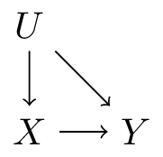

Figure 1: DAG U

```r
required_pkgs <- c("marginaleffects", "ggplot2", "data.table")
cran_repo <- "https://mirror.lyrahosting.com/CRAN/" # <- a CRAN mirror in the Netherlands, can select another one from here https://cran.r-project.org/mirrors.html

available_pkgs <- available.packages(repos = cran_repo)

for (pkg in required_pkgs) {
  if (!pkg %in% rownames(available_pkgs)) {
    warning(sprintf("Package %s is not available from the configured CRAN repo.", sQuote(pkg)))
    next
  }

  installed_version <- tryCatch(
    as.character(packageVersion(pkg)),
    error = function(e) NA_character_
  )
  cran_version <- available_pkgs[pkg, "Version"]

  if (is.na(installed_version) || compareVersion(installed_version, cran_version) < 0) {
    install.packages(pkg, repos = cran_repo)
  }
}
suppressPackageStartupMessages({
  # Load packages
  library(marginaleffects)
  library(ggplot2)
  library(data.table)
})
source(here::here("practicals", "22_scms", "_makedatas.R"))
datas <- make_datas()

data1 <- datas[["data1"]]
data2 <- datas[["data2"]]
```

The datasets can be downloaded here:

data1.csv

data2.csv

**Notestate the ATE in terms of expected values of ‘do’ expressions**

answer:
$$\text{ATE} = E[Y|\text{do}(X=1)] - E[Y|\text{do}(X=0)] \tag{1}$$

**Notewe did not measure $U$, can we estimate this target query based on the DAG, using the observed data**

answer: no, there is an open back-door path through $U$ which we cannot block as we did not observe that variable

`data1` and `data2` come from the same DAG but from different SCMs

**NoteHow can this be? What does this mean?**

answer: the endogenous variables have the same parents, so the DAG is the same. The structural equations are different

We can estimate four features of the observed distribution: $P(Y=1|X=0),P(Y=1|X=1),P(Y=1),P(X=1)$. Observe that for `data1` and `data2`, these are approximately the same (up to sampling variation)

**TipEstimate them from the observed data**

```r
writeLines((paste0("data1\nP(Y=1|X=0) = ", mean(data1[data1$x==0,"y"]), "\nP(Y=1|X=1) = ", mean(data1[data1$x==1,"y"]), "\nP(Y=1) = ", mean(data1[,"y"]), "\nP(X=1) = ", mean(data1[,"x"]))))
```

```
data1
P(Y=1|X=0) = 0.338174273858921
P(Y=1|X=1) = 0.694980694980695
P(Y=1) = 0.523
P(X=1) = 0.518
```

```r
writeLines((paste0("data2\nP(Y=1|X=0) = ", mean(data2[data2$x==0,"y"]), "\nP(Y=1|X=1) = ", mean(data2[data2$x==1,"y"]), "\nP(Y=1) = ", mean(data2[,"y"]), "\nP(X=1) = ", mean(data2[,"x"]))))
```

```
data2
P(Y=1|X=0) = 0.294466403162055
P(Y=1|X=1) = 0.686234817813765
P(Y=1) = 0.488
P(X=1) = 0.494
```

```r
# mean(data1[data1$x==0,"y"])
# mean(data1[data1$x==1,"y"])
# mean(data1[,"y"])
# mean(data1[,"x"])
#
# mean(data2[data2$x==0,"y"])
# mean(data2[data2$x==1,"y"])
# mean(data2[,"y"])
# mean(data2[,"x"])
```

**NoteUse the fact that `u` is in the data to calculate the actual effect in both datasets, what are the answers?**

```r
fit1 <- glm(y~x*u, data=data1, family=binomial)
fit2 <- glm(y~x*u, data=data2, family=binomial)
avg_comparisons(fit1, variables="x")
```

```
 Estimate Std. Error      z Pr(>|z|)   S  2.5 % 97.5 %
 -0.00897     0.0675 -0.133    0.894 0.2 -0.141  0.123

Term: x
Type: response
Comparison: 1 - 0
```

```r
avg_comparisons(fit2, variables="x")
```

```
 Estimate Std. Error    z Pr(>|z|)     S 2.5 % 97.5 %
    0.393      0.029 13.5   <0.001 136.3 0.336   0.45

Term: x
Type: response
Comparison: 1 - 0
```

**TipExplain how this proves (to statistical error) that our target query was not identified**

answer: there were two datasets with two different underlying models. Both yielded the same distribution in terms of observed variables $X,Y$, but when using the `unobserved` variable $U$, we could see both models had different answers to our query.

# Counterfactual computations

Use the following information on patient John:

- age: 60
- hypertension: true
- diabetes: true
- intervention: weight-loss program
- survival-time: 10

In addition to the following structural equation, where u denotes an (unobserved) exogenous noise variable, such that $E[u] = 0$ (i.e. the mean is 0):

$$\text{survival-time} = 120 - \text{age} - 10*\text{hypertension} - 15*\text{diabetes} + 5*\text{weight-loss-program} + u$$

**Tipcalculate the expected survival time for patients with the same covariate values as John when intervening to give or not give the weight-loss-program**

answer:

$$\begin{align}
E[\text{survival-time}|\text{do}(\text{program}=0),...] &= E[120 - 60 - 10 - 15 + u] \\
&= 120 - 60 - 10 - 15 + E[u] \\
&= 35 + E[u] \\
&= 35 + 0 \\
&= 35 \\
\end{align}$$

$$\begin{align}
E[\text{survival-time}|\text{do}(\text{program}=1),...] &= E[120 - 60 - 10 - 15 + 5 + u] \\
&= 120 - 60 - 10 - 15 + 5 + E[u] \\
&= 40 + E[u] \\
&= 40 + 0 \\
&= 40 \\
\end{align}$$

**TipCalculate the survival time for John, given that he took the weight-loss-program and survived 10 year, if he would not have taken the weigth-loss-program**

answer:

### step 1. abduction: infer John’s u

John’s expected survival time with the program (which he had) was 40 years. He lived for 10 years. We can infer that his $u=-30$

Given John’s $u=-30$ and his other observed values, we can now calculate that his expected survival time was $5$ years if he would not have taken the weight-loss program.

### note:

in this simple linear case, the counterfactual could have been calculated directly, but in general this is not the case

# Meta-learners

**NoteRemember the definition of the conditional average treatment effect (CATE) from lecture 4**

$\text{CATE}(w) = E[y|\text{do}(t=1),w] - E[y|\text{do}(t=0),w]$

**NoteRembember the definition of the T-learner and the S-learner from lecture 4:**

- denote $\tau(w) = E[y|\text{do}(t=1),w] - E[y|\text{do}(t=0),w]$
- T-learner: model $T=0$ and $T=1$ separately (e.g. regression separetely for treated and untreated):
  $$\begin{align}
  \mu_0(w) &= E[Y|\text{do}(T=0),W=w] \\
  \mu_1(w) &= E[Y|\text{do}(T=1),W=w] \\
  \tau(w) &= \mu_1(w) - \mu_0(w)
  \end{align}$$
- S-learner: use $T$ as just another feature
  $$\begin{align}
  \mu(t,w) &= E[Y|T=t,W=w] \\
  \tau(w) &= \mu(1,w) - \mu(0,w)
  \end{align}$$

With the following datasets:

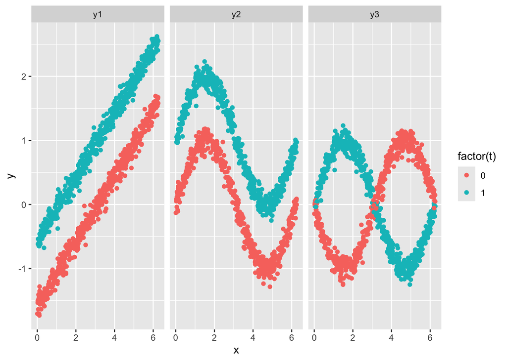

Figure 2: Three datasets with the same DAG

**Tipwhat learning-approach would you recommend for estimating the CATE?**

1. S-learner with simple basemodel and no interaction (e.g. linear regression)
2. S-learner with non-linear base model and no interaction term (e.g. splines / boosting / …)
3. T-learner

NOTE: we typically have data with multi-dimensional features and/or confounders. Having the above plot to decide on the right meta-learning approach is almost never possible.